# Session Nine - Where and How to Get Help

### Unexpected Output

As noted, unexpected output occurs when R produces results we we not anticipating. Here we will look at three possible sources of problems.

**First Problem**

Suppose we want to print “0011” which could be a questionnaire identifier or a binary code.

```r
0011
## [1] 11
```

As you can see when we print on the console, our leading zero’s are dropped and what we are presented with are the two significant digits 11. This is not exactly what we wanted, question therefore is how can you ensure this does not happen and how can we define this problem?

We can define this as a formatting problem given that leading zeros are dropped, hence we need to figure out how to format these values such such that leading zeros are preserved.

**Second Problem**

As a second example, suppose we had the following vector.

```r
input <- c(7/17/2016, 6/17/2016, 5/17/2016, 4/17/2016, 3/17/2017, 2/17/2016, 1/17/2016)
class(input)
## [1] "numeric"
```

We want to convert it into a date object and therefore used “as.Date” function for numeric vectors.

```r
as.Date(input, origin = "1970-01-01" , format = "%m/%d/%Y")
## [1] NA NA NA NA NA NA NA
```

Output generated is a vector with NA or missing dates, not quite what we expected. Question is what went wrong and how can we define this problem.

To define this problem, we need to look at what we passed to “as.Date”. First let us print vector input with our dates.

```r
# Values passed to as.Date
# c(7/17/2016, 6/17/2016, 5/17/2016, 4/17/2016, 3/17/2017, 2/17/2016, 1/17/2016)

# How R interpreted it
input
## [1] 2.042484e-04 1.750700e-04 1.458917e-04 1.167134e-04 8.749162e-05
## [6] 5.835668e-05 2.917834e-05
```

```r
as.Date("1970-01-01") + input
## [1] "1970-01-01" "1970-01-01" "1970-01-01" "1970-01-01" "1970-01-01"
## [6] "1970-01-01" "1970-01-01"
```

Our problem is therefore an input problem and need to figure our how to pass values that “as.Date” will recognize and convert to a date object.

**Third Problem**

As a third example, consider a situation where we have a factor vector with five dates levels. Our interest is to make a plot with means of each date level on the y-axis and their level on the x-axis. Something along these lines.

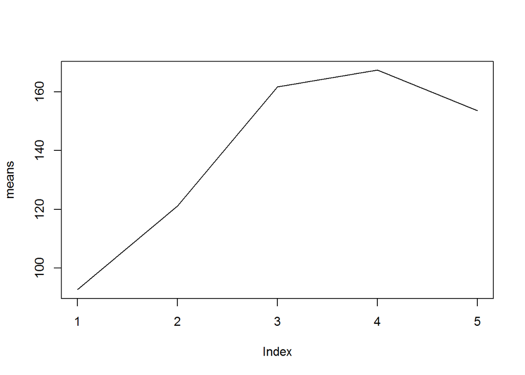

```r
# Data
dat <- seq.Date(as.Date("2016-01-01"), to = as.Date("2016-07-15"), length.out = 5)
dat <- sort(as.factor(sample(dat, 50, replace = TRUE)))
cases <- sample.int(n = 300, length(dat))
means <- tapply(cases, dat, mean)

# Plot
plot(means, type = "l")
```

We have managed to make a plot without an error or warning as values passed were okay. However, we expected labels for x-axis to be date levels rather than indices, question is how were levels changed to indices and how do we solve this problem? But before solving it, we need to define the problem.

This is a problem of axis labeling, we need to get guidance on making custom axis/labels.

With actual problem identified, we can now look for way to solve it.

## Solving (defined) coding problems

In this section we will begin by solving problems posed in the previous section then proceed to discuss in some detail how and where to seek help for problems we are unable to solve.

### Problems where functions are unknown

When functions to be called are unknown, it is best to first ensure we have a good foundation in R. This means making sure we have undertaken a few learning sessions as well as a few practice sessions. With this foundation, as a new R user it is important to start reading “An Introduction to R” manual. This manual is rather hard to understand without some basic knowledge and skills.

At the beginning of our previous section we posed two problems where we did not know functions to call. The first of these was how to get most frequently occurring value in a vector and the other involved getting a function to get matches. To solve these problems, we must begin by reading R’s introduction manual accessible through a call to “help.start()”. We can also search through R’s internal help facilities for certain key words using function “apropos” and/or “help.search”.

Given our first case, skimming through the manual does not yield to a solution; there is no mention of how to get statistical mode, hence we need look outside R. As for the second case, typing “?match” instantly opens help documentation for function “match”. Reading through it we realize we have found our solution.

```r
num1 <- 1:10
num2 <- 5:15
alph1 <- LETTERS[1:10]
alph2 <- LETTERS[5:15]

# Matching values in first vector to second vector
match(num1, num2, nomatch = 0L)
##  [1] 0 0 0 0 1 2 3 4 5 6
match(alph1, alph2, nomatch = 0L)
##  [1] 0 0 0 0 1 2 3 4 5 6

# Returning only matches (values in both vectors)
num2[match(num1, num2, nomatch = 0L) > 0L]
## [1]  9 10 11 12 13 14
alph2[match(alph1, alph2, nomatch = 0L) > 0L]
## [1] "I" "J" "K" "L" "M" "N"

# Alternatively "%in%" can be used (Literary asking "is this in that")
num1 %in% num2; num2[num1 %in% num2]
##  [1] FALSE FALSE FALSE FALSE  TRUE  TRUE  TRUE  TRUE  TRUE  TRUE
## [1]  9 10 11 12 13 14
alph1 %in% alph2; alph1[alph1 %in% alph2]
##  [1] FALSE FALSE FALSE FALSE  TRUE  TRUE  TRUE  TRUE  TRUE  TRUE
## [1] "E" "F" "G" "H" "I" "J"

# A simpler way to extract matches (using set theory in math)
intersect(num1, num2)
## [1]  5  6  7  8  9 10
intersect(alph1, alph2)
## [1] "E" "F" "G" "H" "I" "J"
```

### Problems where functions are known

For problems where we know functions to call but have difficulty getting what we want, the first place for us to search for solutions is R’s inbuilt help documentations. These documentations are accessed with function “help” or starting query with a question mark.

```r
# Pulling up help documentation for function mean
help("mean")
?mean
```

We can also get a good insight to these functions by reading R’s introduction manual. In addition, for add-on/contributed functions we can read the package manual and vignettes. Vignettes are detailed documents about a package. A list of all vignettes can be sourced by calling function “vignette” without passing any argument.

For both base R and add-on/contributed functions, we can ask R to give us a function’s example by calling “example” or give us a demonstration by calling “demo”.

```r
example("mean")

# List of all demos in base R
demo()
```

Now let us try and solve our three type of problems; errors, warnings and unexpected results.

#### Errors

We defined our first problem as a problem of missing column. We can read up on how to add columns to a data frame extractor by pulling up it’s help documentation or asking R to show us sum examples.

```r
?data.frame
?"["
example("data.frame")
example("[")
help("[.data.frame")
```

From documentation on data frame extractor function, we now know we can return all columns by adding a comma after selected rows, this would solve our first problem.

```r
datDF[datDF$status == "Exposed", ]
##    id  status
## 2   2 Exposed
## 4   4 Exposed
## 6   6 Exposed
## 10 10 Exposed
```

Our second problem requires us to start by knowing what “plot.new()” is and how it affects “plot()”. Hence we need to begin by pulling up its help documentation `?plot.new`.

From its help documentation, it is clear that plot.new is a low level function called by all high-level plotting functions. Its main objective is to create or start a new plotting frame or window. Try calling this function without passing any values, a plotting window should be opened.

It is clear what plot.new is and how it comes about and can therefore start to understand what figure margins means. When we changed graphical parameter “mfrow” we essentially added multiple figures to this new plotting window. Each of these figures is padded with some margin as documented by parameter “mar” (par(“mar”)). So the error is simply telling us that this margins are taking a lot of space thereby making it impossible to plot. We can therefore solve this problem by manipulating figure and outer text margin.

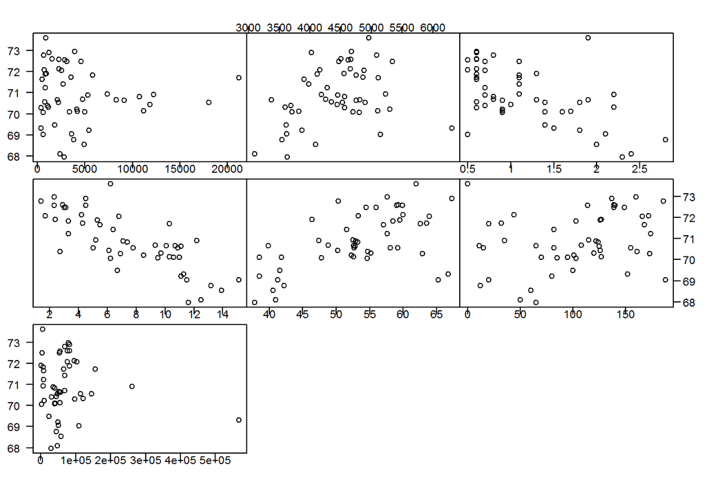

```r
# Documenting original figure layout and margin
original <- par("mfrow", "mar", "oma")

# Reducing figure margins
par(mfrow = c(3, 3), mar = c(1.3, rep(0, 3)), oma = c(rep(2.5, 4)))

# Making first plot
plot(x = state.x77[, "Population"], y = state.x77[,"Life Exp"], xlab = "", ylab = "", xaxt = "n", las = 1)
axis(1, labels = FALSE)
text(x = axTicks(1), y = par("usr")[3] - 0.3, labels = axTicks(1), xpd = NA)

# Making second plot
plot(x = state.x77[, "Income"], y = state.x77[, "Life Exp"], xlab = "", ylab = "", axes = FALSE, frame.plot = TRUE)
axis(3, labels = FALSE)
text(axTicks(3), par("usr")[4] + 0.3, axTicks(3), xpd = NA)

# Making third plot
plot(x = state.x77[, "Illiteracy"], y = state.x77[, "Life Exp"], xlab = "", ylab = "", axes = FALSE, frame.plot = TRUE)
axis(1, labels = FALSE)
text(axTicks(1), par("usr")[3] - 0.3, axTicks(1), xpd = NA)

# Making fourth plot
plot(x = state.x77[, "Murder"], y = state.x77[, "Life Exp"], xlab = "", ylab = "", axes = FALSE, frame.plot = TRUE)
axis(1, labels = FALSE)
text(axTicks(1), par("usr")[3] - 0.3, axTicks(1), xpd = NA)

# Making fifth plot
plot(x = state.x77[, "HS Grad"], y = state.x77[, "Life Exp"], xlab = "", ylab = "", axes = FALSE, frame.plot = TRUE)
axis(1, labels = FALSE)
text(axTicks(1), par("usr")[3] - 0.3, axTicks(1), xpd = NA)

# Making sixth plot
plot(x = state.x77[, "Frost"], y = state.x77[, "Life Exp"], xlab = "", ylab = "", axes = FALSE, frame.plot = TRUE)
axis(1, labels = FALSE)
text(axTicks(1), par("usr")[3] - 0.3, axTicks(1), xpd = NA)
axis(4, labels = FALSE)
text(par("usr")[2] + 15, axTicks(4), labels = axTicks(4), xpd = NA)

# Making seventh plot
plot(x = state.x77[, "Area"], y = state.x77[, "Life Exp"], xlab = "", ylab = "", xaxt = "n", las = 1)
axis(1, labels = FALSE)
text(axTicks(1), par("usr")[3] - 0.3, axTicks(1), xpd = NA)

# Resetting original parameters
par(mfrow = original$mfrow, mar = original$mar, oma = original$oma)
```

#### Warning

When trying to rename a level in a factor vector, we ended up getting NA’s and from warning message given this was a problem of invalid factor level. We therefore need to look up documentation on reassigning factor levels, but what function should we look up?

Looking closely at warning message we see R has given us function to look up, this is “[<-.factor” a function for extracting and replacing parts of a factor vector.

Reading up on this documentation and specifically second sentence under “details” section, we note that value should be a level in the factor vector being reassigned otherwise NA’s are generated with a warning. Clearly this means we used the wrong function in the first place, hence we need to get the correct function.

As before, our next search should be R’s introduction manual. Under chapter four and specifically 4.1, we note function “levels” used to find levels of a factor. Reading through help documentation of “levels” we see there is a “levels(x) <- value” which is used to set or reset levels. This is definitely the function we should use to reassign levels and therefore we have solved or little problem.

```r
indices <- iris$Species == "setosa"
iris$Species[indices]
##  [1] <NA> <NA> <NA> <NA> <NA> <NA> <NA> <NA> <NA> <NA> <NA> <NA> <NA> <NA>
## [15] <NA> <NA> <NA> <NA> <NA> <NA> <NA> <NA> <NA> <NA> <NA> <NA> <NA> <NA>
## [29] <NA> <NA> <NA> <NA> <NA> <NA> <NA> <NA> <NA> <NA> <NA> <NA> <NA> <NA>
## [43] <NA> <NA> <NA> <NA> <NA> <NA> <NA> <NA>
## Levels: setosa versicolor virginica
levels(iris$Species)
## [1] "setosa"     "versicolor" "virginica"
levels(iris$Species)[1] <- "Species1"
levels(iris$Species)
## [1] "Species1"   "versicolor" "virginica"
iris$Species[indices]
##  [1] <NA> <NA> <NA> <NA> <NA> <NA> <NA> <NA> <NA> <NA> <NA> <NA> <NA> <NA>
## [15] <NA> <NA> <NA> <NA> <NA> <NA> <NA> <NA> <NA> <NA> <NA> <NA> <NA> <NA>
## [29] <NA> <NA> <NA> <NA> <NA> <NA> <NA> <NA> <NA> <NA> <NA> <NA> <NA> <NA>
## [43] <NA> <NA> <NA> <NA> <NA> <NA> <NA> <NA>
## Levels: Species1 versicolor virginica
```

#### Unexpected Output

Under this section when defining coding problems we gave an example of integers with leading zeros where we were expecting leading zeros to be printed along side their significant digits. This was however not the case and as they were drop. We concluded by defining the problem as a formatting issue. In that case we will begin by searching formatting documentations.

```r
?format
?formatC
help.search("format")
help.start() # An Introduction to R
```

When you read through these documentations, you will note “formatC” is what we want. formatC() mentions another C-style function “sprintf” capable of doing the same thing.

```r
0011
## [1] 11
sprintf("%04i", 0011)
## [1] "0011"
formatC(0011, width = 4, flag = 0)
## [1] "0011"
```

In our second example, we had a problem with passing values as.Date could understand in order for it to produce date objects. This was a simple issue of reading as.Date’s help documentation.

Under “usage” section, you will note methods (or functions) for “character”, “numeric”, “POSIXct”, and “Date” objects. Each of these methods/functions will work differently, for example, for numeric vectors, values are added to origin (first converted to date if need be) and character objects are first formatted to “year-month-day” and then assigned class “date”.

With this knowledge we can create a date vector by making “input” a character vector and with that we solve an otherwise recurring problem.

```r
# Input as a character object
input <- c("7/17/2016", "6/17/2016", "5/17/2016", "4/17/2016", "3/17/2016", "2/17/2016", "1/17/2016")

# Converting character to date object
dateInput <- as.Date(input, format = "%m/%d/%Y")
dateInput
## [1] "2016-07-17" "2016-06-17" "2016-05-17" "2016-04-17" "2016-03-17"
## [6] "2016-02-17" "2016-01-17"
class(dateInput)
## [1] "Date"
```

Note, for character objects, key conversion argument is format (if it is not similar to “1970-01-01”). For numeric values key argument is origin which is used to computed date.

## Where to get help

Based on preceding discussion we now know how to identify and define coding problems. We can also pull up R’s help documentation as well as its introductory manual. We now need to learn other sources of help and expected ways of getting help.

In general there are two sources of help, internal (within R) and external. Each of these has several sources of help. But none of these sources is relevant without some basic R knowledge, hence we will begin this section by noting some learning platforms and key concepts that an R course should contain. We will proceed to discuss R’s internal sources of help and finally conclude with external sources of help. In each source of help, we will go into detail on how to seek help.

### Knowledge and Skills

There are two sure ways of mastering a program and thereby reducing amount of coding problems, these are knowledge and skills. The more knowledge and skills one gets, the more they become conversant with the program.

There are quite a number of places to learn R given its increasing popularity; courses are being offered in institutions of learning, offices, workshops and online. Whichever learning platforms is selected, there are some key concepts an introductory session should contain, these are.

- Making function calls (everything that happens in R is a result of a function call)
- R’s data structures (including creating and subsetting them)
- Binary operators and
- Conditional statements

Without these concepts, you are bound to get numerous coding problems for which you might not know how to define. On the same note, knowledge on its own is also not enough, one must practice to get a grip on the concepts.

Some of the online platforms offering introductory to advance sessions in R are [data camp](https://www.datacamp.com/courses/free-introduction-to-r), [coursera](https://www.coursera.org/specializations/jhu-data-science), [R bloggers](http://www.r-bloggers.com/) and [youtube](https://www.youtube.com/results?search_query=r+programming+introduction+beginner) channels in R. There is also a package called [swirl](http://swirlstats.com/), when installed and loaded, it turns your console to an interactive learning platform, its a great innovation bound to take you through a novice to an intermediate R user in no time. I would highly recommend you start learning with this package.

As a side note and refresher on mathematical concepts, try [khan Academy](https://www.khanacademy.org).